# Econ 3110: Problem Set 10

## Question 1 (8 points)

**(a) Nash Equilibrium:**  
A set of strategies (one for each player) is a Nash Equilibrium if no player can unilaterally change their strategy to increase their payoff, holding the strategies of all other players constant. Formally, a strategy profile $s^*$ is a Nash Equilibrium if $u_i(s_i^*, s_{-i}^*) \geq u_i(s_i, s_{-i}^*)$ for all strategies $s_i$ and all players $i$.

**(b) A Subgame:**  
In an extensive-form game, a subgame is a subset of the game that starts at a specific node (a singleton information set), includes all subsequent nodes and decision branches derived from that node, and preserves the information structure of the original game.

**(c) Subgame-Perfect Nash Equilibrium (SPNE):**  
A strategy profile is a Subgame-Perfect Nash Equilibrium if it induces a Nash Equilibrium in every possible subgame of the original game. This concept eliminates non-credible threats.

**(d) Stackelberg Competition:**  
A model of imperfect competition where firms compete on quantity (like Cournot), but moves are sequential. There is a "leader" firm that moves first, and a "follower" firm that moves sequentially after observing the leader's output.

**(e) Bertrand Competition:**  
A model of imperfect competition where firms compete by setting prices simultaneously. In the standard model with homogeneous goods, this leads to price equaling marginal cost ($P=MC$).

## Question 2 (4 points)

**(a) Claim: In the long-run, the number of plants in the industry and their output is undetermined.**  
**Status: FALSE**  
**Explanation:** The prompt states $F(K,L)$ is strictly increasing but does not specify the returns to scale (e.g., increasing, constant, or decreasing).

1. If the technology exhibits **Constant Returns to Scale (CRS)**, the Long-Run Average Cost (LRAC) curve is horizontal. Firm size is indeterminate (any output level is efficient), making the number of plants indeterminate.
2. If it implies **Decreasing Returns to Scale**, optimal firm size is infinitesimal.
3. If **Increasing Returns to Scale**, the industry tends toward a natural monopoly (1 firm). Because the outcome depends on the returns to scale (which are not specified), the statement is uncertain. The prompt requires choosing **False** if the statement is uncertain.

**(b) Claim: If Hermione is a profit-maximizer, then her optimal choice of labour ($L^*$) is indeterminate.**  
**Status: TRUE**  
**Explanation:** A strictly increasing and convex production function implies **Increasing Returns to Scale (IRS)** and increasing Marginal Product of Labor ($MP_L$). Consequently, Marginal Cost ($MC$) is decreasing. A competitive profit-maximizing firm sets $P = MC$. However, with falling $MC$:

- If $P > MC$, the firm increases profit by producing more. Since $MC$ falls as $Q$ rises, $P > MC$ holds as output expands, leading to infinite demand for labor.
- Mathematically, the profit function $\pi(L) = P \cdot F(L) - C(L)$ is convex. The maximum lies at a corner solution ($L=0$ or $L=\infty$). **Since the firm’s optimal output is infinite (corner solution at $\infty$), a finite profit-maximizing labor choice $L^*$ does not exist.**

## Question 3 (6 points)

**Parameters:** $a > 0$, $b > c > 0$.  
**Inverse Demand:**  
$p_1 = a - bq_1 - cq_2$  
$p_2 = a - bq_2 - cq_1$  
**Costs:** $MC=0, FC=0$.

Cournot Output ($q$): $$\frac{a}{2b + c}$$
Cournot Price ($p$): $$\frac{ab}{2b + c}$$
Bertrand Price ($p$): $$\frac{a(b - c)}{2b - c}$$
Bertrand Output ($q$): $$\frac{ab}{2b^2 + bc - c^2}$$

### Answers for Q3

**(b) Bertrand Equilibrium**
Using the direct demand functions derived from inverting the system: $$ p_1^B = p_2^B = \frac{a(b-c)}{2b - c} $$ $$ q_1^B = q_2^B = \frac{a b}{(b+c)(2b-c)} $$

**(c) Comparison and Intuition**

- **Output:** Cournot quantity is lower than Bertrand quantity.
- **Price:** Cournot price is higher than Bertrand price.
- **Intuition:** In Cournot competition, firms choose quantities, taking the other's quantity as given. This allows them to maintain higher prices by restricting output. In Bertrand competition, firms compete on price. Even with imperfect substitutes ($b > c$), the incentive to undercut the rival to steal market share is stronger, driving prices down closer to marginal cost (though not exactly to MC=0 due to product differentiation).

## Question 4 (6 points)

**Utility Functions:**

- $u_1(x_A, x_B) = \sqrt{x_A} + \sqrt{x_B}$
- $u_2(x_A, x_B) = x_A + x_B$

**Endowments:** $e_1 = (1, 0), e_2 = (0, 1)$. Total $A=1, B=1$.

**(a) Set of Pareto-efficient allocations**  
Pareto efficiency requires $MRS_1 = MRS_2$.

- $MRS_1 = \frac{MU_A}{MU_B} = \frac{0.5/\sqrt{x_{1A}}}{0.5/\sqrt{x_{1B}}} = \sqrt{\frac{x_{1B}}{x_{1A}}}$
- $MRS_2 = 1$ (Perfect substitutes)

Setting $MRS_1 = MRS_2$: $$ \sqrt{\frac{x_{1B}}{x_{1A}}} = 1 \implies x_{1B} = x_{1A} $$ The Pareto set is the diagonal line where Farmer 1 consumes equal amounts of Apples and Bananas ($x_{1A} = x_{1B}$). Consequently, Farmer 2 also consumes equal amounts ($x_{2A} = x_{2B}$).

**(b) Edgeworth Box Visualization**

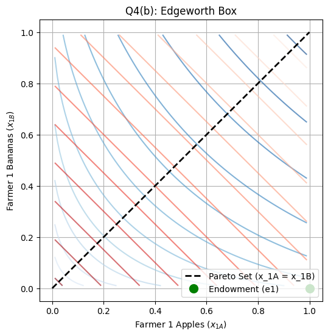

**(c) Analysis with $u_2(x_A, x_B) = x_A^{1+\epsilon} + x_B^{1+\epsilon}$**  
If $\epsilon > 0$, Farmer 2's utility function becomes strictly convex. This implies their indifference curves (relative to the origin $O_2$) are **bowed out** (concave to the origin $O_2$, or simply "bowed towards the middle of the box"). Farmer 2 prefers extreme bundles (all Apples or all Bananas) over mixtures.

On the diagram, Farmer 2's indifference curves would look like quarter-circles centered away from $O_2$. The tangency condition with Farmer 1's convex preferences (standard convex-to-origin ICs) would likely occur at minimums rather than maximums, or trade would be pushed to the **boundaries**.

**Is the Pareto set unchanged?**  
**No.** Because Farmer 2 prefers extremes, efficiency requires moving to the edges of the box. The Pareto efficient allocations will likely consist of the edges where Farmer 2 consumes only one good (e.g., the bottom and right edges of the box from Farmer 1's perspective).

## Question 5 (6 points)

**Preferences:**

- Kanto ($K$): $u_K = D_K + 2A_K$ ($MRS_{DA}^K = 1/2$)
- Johto ($J$): $u_J = 2D_J + A_J$ ($MRS_{DA}^J = 2$)

Note: $MRS_{DA} = MU_D / MU_A$. The marginal rate of substitution is constant for both agents (linear indifference curves).

- K values A relatively more ($1 D$ trades for $0.5 A$ to keep utility constant).
- J values D relatively more ($1 D$ trades for $2 A$ to keep utility constant).

Since $MRS^K < MRS^J$ everywhere ($0.5 < 2$), mutually beneficial trade exists until one agent hits a constraint (runs out of a good). Efficiency requires the agent who values a good most to hold it.

- K should hold Apples.
- J should hold Dratinis.

**(a) Pareto-efficient allocations and Contract Curve (Initial Endowment)** Total Endowments: $D_{tot}=1000, A_{tot}=1000$. Pareto Set consists of allocations where K holds as many Abras as possible and J holds as many Dratinis as possible.

1. **Top Edge:** K has all 1000 Abras ($A_K=1000$), J has 0. ($D_K$ varies).
2. **Left Edge:** J has all 1000 Dratinis ($D_K=0$), K has 0. ($A_K$ varies).

The **Contract Curve** is the subset of Pareto efficient points reachable via mutually beneficial trade from the endowment $(D_K=1000, A_K=0)$.

- At endowment: $u_K = 1000$, $u_J = 1000$.
- Trade Logic: K trades D for A. J trades A for D.
- Resulting Equilibrium: K ends up with all Abras (and some Dratinis if A is cheaper than relative value) or J ends up with all Dratinis. Given the symmetry and linear preferences, they likely move to the corner $(D_K=0, A_K=1000)$.

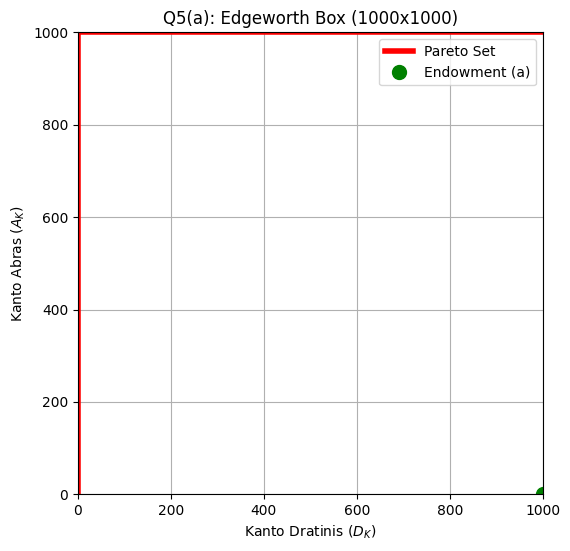

**(b) Set of allocations for Contract Curve** The contract curve connects the endowment to the Pareto set. However, technically the Contract Curve is the set of Pareto Optimal points where $u_i \geq u_{i,0}$. From $e=(1000, 0)$, they trade until K has all Abras. The efficient point $(0, 1000)$ gives $u_K=2000, u_J=2000$. Both are better off.

- K should hold all A ($A_K=1000$).
- J should hold all D ($D_J=1500 \implies D_K=0$). Pareto set is the L-shaped boundary: Top Edge ($A_K=1000$) and Left Edge ($D_K=0$).

**Contract Curve:** Subset of Pareto set improving on new endowment utilities. Endowment: $u_K = 500 + 0 = 500$. $u_J = 2(1000) + 1000 = 3000$. Efficient points must satisfy $u_K \geq 500$ and $u_J \geq 3000$.

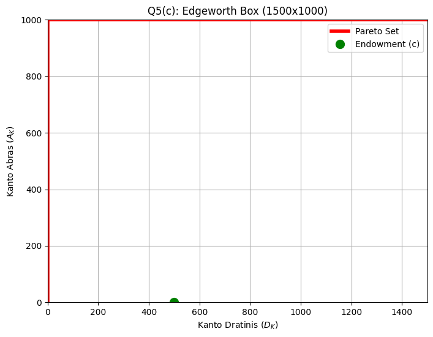